## Deep Learning Assignment2 Q1 - Group 255

| Name | StudentID | Contribution |
| --- | --- | --- |
| AMOGH SINGHAL | 2020SC04081 | 100% |
| ABHAY DATTARAY THAPAN | 2020SC04431 | 100% |
| AKSHIT AGRAWAL | 2020SC04956 | 100% |

# Table of contents available for navigtion

### Use `JupyterLab` for better experience

# 1.Import Libraries/Dataset (0 mark)

## Import the required libraries

```python
# tensorflow version
import tensorflow as tf
print('tensorflow: %s' % tf.__version__)
# keras version
import keras
print('keras: %s' % keras.__version__)
```

```
tensorflow: 2.8.2
keras: 2.8.0
```

```python
# Mount Google drive
from google.colab import drive
drive.mount('/content/drive')
```

## Check the GPU available (recommended- use free GPU provided by Google Colab).

```python
# code to check if GPU is enabled or not
device_name = tf.test.gpu_device_name()
if device_name != '/device:GPU:0':
  raise SystemError('ERROR ::: GPU device not found')
print('SUCCESS ::: Found GPU at: {}'.format(device_name))
```

```
SUCCESS ::: Found GPU at: /device:GPU:0
```

# 2.Data Processing(1 mark)

## Read the pickle file

(https://drive.google.com/file/d/1pcFPrRGGk0kEzLXlfIDrAvRZbTBiVeET/view?usp=sharing) (Links to an external site.) and convert the data into the correct format which could be used for ML model.

Pickle file contains the image id and the text associated with the image.

Eg: '319847657_2c40e14113.jpg#0\tA girl in a purple shirt hold a pillow .

Each image can have multiple captions.

`319847657_2c40e14113.jpg` -> image name

`#0` -> Caption ID

`\t` -> separator between Image name and Image Caption

`A girl in a purple shirt hold a pillow .` -> Image Caption

Corresponding image wrt image name can be found in the image dataset folder.

Image dataset Folder : https://drive.google.com/file/d/1-mPKMpphaKqtT26ZzbR5hCHGedkNyAf1/view?usp=sharing

### Creation of `image_captions_data'

```python
# open the pickle file and stream back the structure

import pickle
pkl_path = '/content/drive/MyDrive/Colab Notebooks/image_captioning/set_0.pkl'
with open(pkl_path, 'rb') as image_captions:
  image_captions_data = pickle.load(image_captions)

# Type of data serialized
print(type(image_captions_data))

# Print Top 5 elements of the captions
print("\nData From Image Captions")
print("------------------------")
print("\n".join(image_captions_data[:5]))
```

```
<class 'list'>

Data From Image Captions
------------------------
318667317_108c402140.jpg#4	A man in a black hoodie be hold a paper sign .
2072574835_febf0c5fb9.jpg#4	Three race dog be run out of the start gate on a track .
3083016677_5782bc337c.jpg#4	Two motorcycle with two rider each .
95734038_2ab5783da7.jpg#0	A man on a bike nest to a river .
241346146_f27759296d.jpg#1	A football player try tackle another player who have the ball .
```

## Unzipping the images data

```python
#!unzip "/content/drive/MyDrive/Colab Notebooks/image_captioning/Image_captioning_Dataset.zip" -d "/content/drive/MyDrive/Colab Notebooks/image_captioning"
```

[output not shown]

[output cut: 4946 more lines]

[output not shown]

## Count number of images extracted

```python
import os

# folder path
dir_path = r'/content/drive/MyDrive/Colab Notebooks/image_captioning/Flicker8k_Dataset'
count = 0
# Iterate directory
for path in os.listdir(dir_path):
    # check if current path is a file
    if os.path.isfile(os.path.join(dir_path, path)):
        count += 1
print('File count:', count)
# output: File count: 8091
```

```
File count: 8091
```

## Excluding files which are present in pickle but NOT part of dataset

```python
import os

exclude_files = list()
for i in range(len(image_captions_data)):
  image_name = image_captions_data[i].split('#')[0]
  image_name_with_path = os.path.join(dir_path, image_name)

  if not os.path.isfile(image_name_with_path):
    exclude_files.append(image_captions_data[i])
    print(image_name_with_path)
```

```
/content/drive/MyDrive/Colab Notebooks/image_captioning/Flicker8k_Dataset/2258277193_586949ec62.jpg.1
/content/drive/MyDrive/Colab Notebooks/image_captioning/Flicker8k_Dataset/2258277193_586949ec62.jpg.1
/content/drive/MyDrive/Colab Notebooks/image_captioning/Flicker8k_Dataset/2258277193_586949ec62.jpg.1
/content/drive/MyDrive/Colab Notebooks/image_captioning/Flicker8k_Dataset/2258277193_586949ec62.jpg.1
```

```python
# print details of files before and after dropping out
print(exclude_files)
print("Size before deletion: {}".format(len(image_captions_data)))
for i in range(len(exclude_files)):
  image_captions_data.remove(exclude_files[i])
print("Size after deletion: {}".format(len(image_captions_data)))
```

```
['2258277193_586949ec62.jpg.1#3\tThree person stand at a station .', '2258277193_586949ec62.jpg.1#1\tSome person look out window in a large building .', '2258277193_586949ec62.jpg.1#4\ttwo woman and one man stand near train track .', '2258277193_586949ec62.jpg.1#0\tperson wait for a subway']
Size before deletion: 25000
Size after deletion: 24996
```

## Plot at least two samples and their captions (use matplotlib/seaborn/any other library).

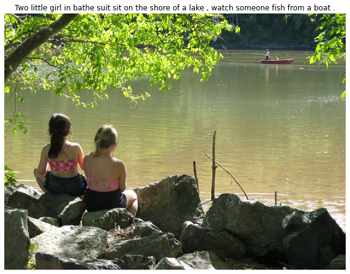

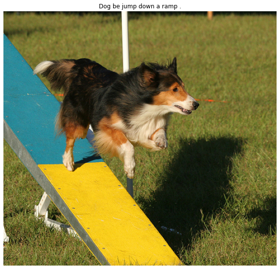

```python
# plot at least two samples and their captions
# (use matplotlib/seaborn/any other library).
import matplotlib.pyplot as plt
import matplotlib.image as mpimg
import random
import os

# image dataset path
image_dataset_path = '/content/drive/MyDrive/Colab Notebooks/image_captioning/Flicker8k_Dataset'
# initiate a dictionary to have two random image names
random_image_names = {}

# loop through to get the image names from the list
while(len(random_image_names) < 2):
  random_index = random.randint(0, len(image_captions_data) - 1)
  image_name = image_captions_data[random_index].split('#')[0]
  random_image_names[image_name] = random_index

# display the image with caption
for image_name  in random_image_names:
  plt.figure(figsize=(10,10))
  img = mpimg.imread(os.path.join(image_dataset_path, image_name))
  imgplot = plt.imshow(img)
  plt.title(image_captions_data[random_image_names[image_name]].split('\t')[1])
  plt.axis('off')
  plt.show()
```

## Bring the train and test data in the required format.

### Creation of `image_caption_data_list`

```python
import pandas as pd
import os

# split the data and organize into tabular form
image_caption_data_list = {}

# loop through image caption information
for i in range(len(image_captions_data)):
  # split Each line to separate files from rest
  icd_split = image_captions_data[i].split('#')
  # icd_split[0] - image name
  # icd_split[1] - image caption
  # split rest of the script to separate id no from description
  icd_cap_split = icd_split[1].split('\t')
  # generate image id from the filename without extention
  image_id = icd_split[0].split('.') [0]

  #Initiate image_caption_data_list dictionary as empty list
  if image_id not in image_caption_data_list:
    image_caption_data_list[image_id] = list()
  #Append data to list
  image_caption_data_list[image_id].append('' if len(icd_cap_split) < 2 else icd_cap_split[1])

#Print top 5 entries from the data
i = 0
for image in image_caption_data_list:
  print (image, image_caption_data_list[image])
  if i > 5:
    break
  i += 1

df = pd.DataFrame(data=image_caption_data_list.items(), columns=['imagename', 'caption'])
print("Shape of dataframe: ", df.shape)
df.head()
```

```
318667317_108c402140 ['A man in a black hoodie be hold a paper sign .', 'A homeless man carry a sign that say " hungry " .', 'A bearded man hold a sign .', 'A man in a black hoodie hold a small sign .']
2072574835_febf0c5fb9 ['Three race dog be run out of the start gate on a track .', 'Greyhound dog wear race stripe be run out of a gate on a track .', 'Dog in a race .']
3083016677_5782bc337c ['Two motorcycle with two rider each .', 'There be two motorcycle with a man and a woman on it .', 'Two guy with helmet be on motorcycle , each with a woman ride behind him', 'Two motorcycle and four rider be on a road .']
95734038_2ab5783da7 ['A man on a bike nest to a river .', 'A man ride a bicycle on a rocky path beside a lake in the mountain .', 'A man stand astride a bike on a rocky trail by a lake .']
241346146_f27759296d ['A football player try tackle another player who have the ball .', 'A Sooner football player carry the ball be try to avoid be tackle .', 'A football player be run with the ball as a player of the oppose team grab his leg']
3182405529_7692256746 ['an old man with long gray hair and a long gray beard bike ride on the shore .', 'A white-bearded man ride a bicycle on a beach .']
3278777548_290b881018 ['Four person walk on a bridge over a body of water .', 'Four person be walk on a bridge .']
Shape of dataframe:  (8036, 2)
```

|  | imagename | caption |
| --- | --- | --- |
| 0 | 318667317_108c402140 | [A man in a black hoodie be hold a paper sign ... |
| 1 | 2072574835_febf0c5fb9 | [Three race dog be run out of the start gate o... |
| 2 | 3083016677_5782bc337c | [Two motorcycle with two rider each ., There b... |
| 3 | 95734038_2ab5783da7 | [A man on a bike nest to a river ., A man ride... |
| 4 | 241346146_f27759296d | [A football player try tackle another player w... |

# 3.Model Building (4 mark)

## Use Pretrained VGG-16 model trained on ImageNet dataset (available publicly on google) for image feature extraction.

```python
from os import listdir
from pickle import dump
from keras.applications.vgg16 import VGG16
from keras.preprocessing.image import load_img
from keras.preprocessing.image import img_to_array
from keras.applications.vgg16 import preprocess_input
from keras.models import Model
import sys


#Extract features from each photo
def extract_features(directory):

  # load the model
  model = VGG16(weights='imagenet')

  # restructure the model
  model = Model(inputs=model.inputs, outputs = model.layers[-2].output)
  print(model.summary())

  # extract features from each photo
  features = dict()

  # for name in listdir(directory):
  total_no_files = len(image_caption_data_list)
  count = 1
  for name in image_caption_data_list:
    sys.stdout.write("\rProcessing :" + str(count) + " out of :" + str(total_no_files))
    sys.stdout.flush()

    # load image from file
    filename = os.path.join(directory, name + '.jpg')
    image = load_img(filename, target_size=(224, 224))

    # convert the image pixels to numpy array
    image = img_to_array(image)

    # reshape data for the model (num_images, height, width, num_channels)
    # (224, 224, 3)
    image = image.reshape((1, image.shape[0], image.shape[1], image.shape[2]))

    # prepare image for VGG model
    image = preprocess_input(image)

    # get features
    feature = model.predict(image, verbose=0)

    # get image id
    image_id = name.split('.')[0]
    features[image_id] = feature
    count = count + 1
  return features
```

## Saving the `features.pkl` file

```python
# NOTE: Run this only once if pickle file does not exist !!
# features_file = '/content/drive/MyDrive/Colab Notebooks/image_captioning/dataset_features.0.pkl'

# call function to extract features from all images.
# features = extract_features(image_dataset_path)
# print("Total No Features: {}".format(len(features)))
# save features to file
# dump(features, open(features_file, 'wb'))
```

[output not shown]

## Loading the `features.pkl` file

```python
from pickle import load

# read from features pkl file
features_file = '/content/drive/MyDrive/Colab Notebooks/image_captioning/dataset_features.0.pkl'
features = load(open(features_file, 'rb'))
print("Total No Features: {}".format(len(features)))
# output: Total No Features: 8036
```

```
Total No Features: 8036
```

## Preprocessing and tokenizing the captions data

```python
#Preprocess the captions and bring them to tokenized form

import re
import string
import nltk
nltk.download('stopwords')
nltk.download('punkt')
nltk.download('omw-1.4')
from nltk.corpus import stopwords
from nltk.tokenize import word_tokenize
from nltk.stem import WordNetLemmatizer
nltk.download('wordnet')
lemmatizer = WordNetLemmatizer()

#Preprocess the existing captions
stop_words = set(stopwords.words('english'))

#Loop through each image
for image_id in image_caption_data_list:
  #For each image id, preprocess each item in the list
  for i in range(len(image_caption_data_list[image_id])):
    description = image_caption_data_list[image_id][i]
    # remove URLS
    description = re.sub(r"http\S+|www\S+|https\S+", '', description, flags=re.MULTILINE)
    # remove special characters
    description = re.sub(r'\@\w+|\#','', description)
    # remove the punctuations
    description = re.sub(r'[!"#$%&\'()*+,-./:;<=>?@\[\]^_`{|}~]','',description)
    # convert tweets into lowercase
    description = description.lower()
    # remove tokens with numbers in them
    description = [w for w in description if w.isalpha()]
    # remove hanging 's' and 'a'
    description = " ".join([w for w in description if len(w)>1])

    #Remove stopwords
    # description = " ".join([w for w in word_tokenize(description) if not w in stop_words])
    #Lemmatization - usually refers to doing things properly using vocabulary and morphological analysis of words.
    # description = "".join([lemmatizer.lemmatize(w, pos='a') for w in description])
    #Add start and end identifiers
    description = 'startseq' + ' ' + description + ' ' + 'endseq'
    image_caption_data_list[image_id][i] = description

#Print Top 5 entries of dictionary
cnt = 0
for item in image_caption_data_list:
  print(item, image_caption_data_list[item])
  cnt += 1
  if cnt > 5:
    break
```

[output not shown]

### Saving the `image_caption_data_list` dict as a pickle file for later use

```python
# NOTE: Run this only once if clean description pickle file does not exist !!
clean_descriptions = '/content/drive/MyDrive/Colab Notebooks/image_captioning/clean_descs.pkl'

# save features to file
dump(image_caption_data_list, open(clean_descriptions, 'wb'))
```

### Generate the vocabulary

```python
# generate vocabulary list
all_vocabulary = set()

# split all descriptions and dump into vocabulary set
for item in image_caption_data_list:
  all_vocabulary.update(' '.join(image_caption_data_list[item]).split())
  #print(item)
all_vocabulary_count = len(all_vocabulary)
print(len(all_vocabulary))
# output: 5399 -- older vocab size after removing stop words and lemmatization
```

[output not shown]

### Deriving the max length description among all the sequences

```python
# Generate max length of descriptions
max_lengthed_description = 0
total_length = 0
total_string_count = 0
for item in image_caption_data_list:
  for caption in image_caption_data_list[item]:
    total_string_count += 1
    total_length += len(caption.split())
    if max_lengthed_description < len(caption.split()):
      max_lengthed_description = len(caption.split())
      if len(caption.split()) == 21:
        print(caption)

print("Max lengthed description from the list = {}".format(max_lengthed_description))
print("Average length: {}".format(total_length/total_string_count))

# output
# Max lengthed description from the list = 21
# Average length: 8.212834053448551
```

[output not shown]

### Saving description as a `txt` file (Optional)

```python
# Save description to a text file
lines = list()
for item in image_caption_data_list:
  for caption in image_caption_data_list[item]:
    lines.append(' '.join([item, caption]))
print('No of lines {}.'.format(len(lines)))
caption_filename = '/content/drive/MyDrive/Colab Notebooks/image_captioning/descriptions.txt'
with open(caption_filename, 'w') as capf:
  capf.write('\n'.join(lines))

# output : No of lines 24996.
```

```
No of lines 24996.
```

### Data Splitting into Train, Val and Test

```python
#Split the data into train, validation, test with size of 70%, 10% and 20%
import random

image_caption_data_dict_to_list = list()
for item in image_caption_data_list:
  image_caption_data_dict_to_list.append([item, image_caption_data_list[item]])


train_data_size = int(abs(len(image_caption_data_dict_to_list) * 0.7))
validate_data_size = int(abs(len(image_caption_data_dict_to_list) * 0.1))
test_data_size = int(len(image_caption_data_dict_to_list) - train_data_size - validate_data_size)
print("Split count: Train = {}, Validate = {}, Test = {}".format(train_data_size, validate_data_size, test_data_size))

random_index = list(range(len(image_caption_data_dict_to_list)))
random.shuffle(random_index)
print("Random Index size: {}".format(len(random_index)))
print("Top 10 index: {}".format(random_index[:10]))

start_index_train_data_size = 0
end_index_train_data_size = train_data_size - 1
print("Train Data index: [start: {}][end: {}]".format(start_index_train_data_size, end_index_train_data_size))
start_index_validate_data_size = end_index_train_data_size + 1
end_index_validate_data_size = start_index_validate_data_size + validate_data_size - 1
print("Validate Data index: [start: {}][end: {}]".format(start_index_validate_data_size, end_index_validate_data_size))
start_index_test_data_size = end_index_validate_data_size + 1
end_index_test_data_size = start_index_test_data_size + test_data_size - 1
print("Train Data index: [start: {}][end: {}]".format(start_index_test_data_size,end_index_test_data_size))

train_data_list = image_caption_data_dict_to_list[start_index_train_data_size: end_index_train_data_size + 1]
train_validate_list = image_caption_data_dict_to_list[start_index_validate_data_size: end_index_validate_data_size + 1]
train_test_list = image_caption_data_dict_to_list[start_index_test_data_size: end_index_test_data_size + 1]
print("Dataset Size: Train [{}] Validate [{}] Test [{}]".format(len(train_data_list), len(train_validate_list), len(train_test_list)))

print(type(image_caption_data_dict_to_list))

# output
# Split count: Train = 5625, Validate = 803, Test = 1608
# Random Index size: 8036
# Top 10 index: [981, 1696, 1054, 67, 5535, 6477, 6087, 6584, 2121, 6947]
# Train Data index: [start: 0][end: 5624]
# Validate Data index: [start: 5625][end: 6427]
# Train Data index: [start: 6428][end: 8035]
# Dataset Size: Train [5625] Validate [803] Test [1608]
# <class 'list'>
```

```
Split count: Train = 5625, Validate = 803, Test = 1608
Random Index size: 8036
Top 10 index: [5276, 1556, 1008, 6805, 4174, 6, 2742, 5952, 4042, 3461]
Train Data index: [start: 0][end: 5624]
Validate Data index: [start: 5625][end: 6427]
Train Data index: [start: 6428][end: 8035]
Dataset Size: Train [5625] Validate [803] Test [1608]
<class 'list'>
```

### Sequence Generation

```python
# Generate sequences
from keras.preprocessing.text import Tokenizer
from tensorflow.keras.preprocessing.sequence import pad_sequences
from tensorflow.keras.utils import to_categorical

all_descriptions = list()
for item in image_caption_data_list:
  for i in range(len(image_caption_data_list[item])):
    all_descriptions.append(image_caption_data_list[item][i])

import numpy as np
print(len(all_descriptions))
print(all_descriptions[:5])

tokenizer = Tokenizer()
tokenizer.fit_on_texts(all_descriptions)
vocabulary_size = len(tokenizer.word_index) + 1

print('Vocabulary Size: {}'.format(vocabulary_size))
print((tokenizer.word_index))

def data_generator(data):
  count = 0
  while 1:
    for element in range(len(data)):
      X1, X2, y = list(), list(), list()
      for i in range(len(data[element][1])):
        split_description = data[element][1][i].split()
        seq = tokenizer.texts_to_sequences([' '.join(split_description[1:])])[0]
        for i in range(1, len(seq)):

          # split into input and output
          in_sequence, out_sequence = seq[:i], seq[i]

          # pad input sequence
          in_sequence = pad_sequences([in_sequence], maxlen=max_lengthed_description)[0]
          out_sequence = to_categorical([out_sequence], num_classes=vocabulary_size)[0]
          image_feature = features[data[element][0]][0]

          print(image_feature.shape)
          print(image_feature.shape, in_sequence, out_sequence)

          X1.append(image_feature)
          X2.append(in_sequence)
          y.append(out_sequence)
        count += 1
        yield [[np.array(X1), np.array(X2)], np.array(y)]
    # print(len(array(X1)), len(array(X2)), len(array(y)))
    # print(np.array(X1).shape, np.array(X2).shape, np.array(y).shape)
    # for i in range(10):
    #   print(X2[i], np.argmax(y[i]))
    # if count > 5:
    #   break
    # break


data_generator(train_data_list)

# output
# 24996
# ['beginsentence man black hoodie hold paper sign endsentence', 'beginsentence homeless man carry sign say hungry endsentence', 'beginsentence bearded man hold sign endsentence', 'beginsentence man black hoodie hold small sign endsentence', 'beginsentence three race dog run start gate track endsentence']
# Vocabulary Size: 5400

# <generator object data_generator at 0x7faf5cdbcb50>
```

[output not shown]

```
<generator object data_generator at 0x7f7dc447f4d0>
```

# 4.Model Compilation (0.5 mark)

## Create 3 layered RNN layer model and other relevant layers for image caption generation.

## Add L2 regularization to all the RNN layers.

## Add one layer of dropout at the appropriate position and give reasons.

## Compile the model with the appropriate loss function.

## Use an appropriate optimizer. Give reasons for the choice of learning rate and its value.

```python
#Model Building Libraries
from numpy import array
import tensorflow
from pickle import load
from tensorflow.keras.preprocessing.text import Tokenizer
from tensorflow.keras.preprocessing.sequence import pad_sequences
from tensorflow.keras.utils import to_categorical, plot_model
from tensorflow.keras.layers import Input, Dense, LSTM, Embedding, Dropout, SimpleRNN
from tensorflow.keras.models import Model
from keras.layers.merge import add
from tensorflow.keras.callbacks import ModelCheckpoint
from tensorflow.keras import regularizers

#Design the model

#Inputs
inputs1 = Input(shape=(1000,))
fe1 = Dropout(0.5)(inputs1)
fe2 = Dense(256, activation='relu')(fe1)

inputs2 = Input(shape=(max_lengthed_description,))
se1 = Embedding(vocabulary_size, 256, mask_zero=True)(inputs2)
se2 = Dropout(0.5)(se1)

se3 = LSTM(256, kernel_regularizer='l2', recurrent_regularizer='l2',return_sequences=True)(se2)
#As process taking too long time to process, reducing the layers
se4 = LSTM(256, kernel_regularizer='l2', recurrent_regularizer='l2', return_sequences=True)(se3)
se5 = LSTM(256, kernel_regularizer='l2', recurrent_regularizer='l2')(se4)

decoder1 = add([fe2, se5])
decoder2 = Dense(256, activation='relu')(decoder1)
outputs = Dense(vocabulary_size, activation='softmax')(decoder2)

model = Model(inputs=[inputs1, inputs2], outputs=outputs)
model.compile(loss='categorical_crossentropy', optimizer='adam', metrics='accuracy')

print(model.summary())
plot_model(model, to_file='model.png', show_shapes=True)

#Dropping out at input layer, embeding layer and LSTM layer tried. Non of them resulted in any kind of improvement in final accuracy.
#Default lerning rate worked better.
```

[output not shown]

# 5.Model Training (1 mark)

## Use generators to avoid `Memoryerror`

### data is generated in parallel by the `CPU` and then directly fed to the `GPU`.

```python
import time

# define checkpoint callback
filepath = 'model-ep{epoch:03d}-loss{loss:.3f}-val_loss{val_loss:.3f}.h5'
checkpoint = ModelCheckpoint(filepath, monitor='val_loss', verbose=1, save_best_only=True, mode='min')


start = time.time()
history = model.fit_generator(generator=data_generator(train_data_list),
                              epochs=20,
                              steps_per_epoch=len(train_data_list)/32,
                              verbose=2,
                              validation_data=data_generator(train_validate_list),
                              validation_steps=len(train_validate_list)/32,
                              callbacks=[checkpoint]
                              )
end = time.time()

print("Total time spent in training the model...")
print(f"{round((end-start),2)} seconds...")
```

[output not shown]

[output not shown]

[output cut: 4699 more lines]

[output not shown]

## Saving the model

```python
# saving the model

model_path = '/content/drive/MyDrive/Colab Notebooks/image_captioning/model_20220906.h5'
model.save(model_path)
```

## Loading the model

```python
# load the model

model_path = '/content/drive/MyDrive/Colab Notebooks/image_captioning/model_20220906.h5'
model = tf.keras.models.load_model(model_path)
model
```

```
<keras.engine.functional.Functional at 0x7f7dc3f327d0>
```

## Plot the loss and accuracy history graphs for both train and validation set.

```
dict_keys(['loss', 'accuracy', 'val_loss', 'val_accuracy'])
```

[figure not shown]

[figure not shown]

```python
# list all data in history
print(history.history.keys())

# summarize history for accuracy
plt.plot(history.history['accuracy'])
plt.plot(history.history['val_accuracy'])
plt.title('model accuracy')
plt.ylabel('accuracy')
plt.xlabel('epoch')
plt.legend(['train', 'test'], loc='upper left')
plt.show()

# summarize history for loss
plt.plot(history.history['loss'])
plt.plot(history.history['val_loss'])
plt.title('model loss')
plt.ylabel('loss')
plt.xlabel('epoch')
plt.legend(['train', 'test'], loc='upper left')
plt.show()
```

```python
#Return word from the tokenizer dictionary
from nltk.translate.bleu_score import sentence_bleu
from nltk.translate.bleu_score import corpus_bleu

def wordID(ID):
  for word, index in tokenizer.word_index.items():
    if ID == index:
      return word
  return None

def generate_description(imageID):
  in_text = 'startseq'
  for i in range(max_lengthed_description):
    sequence = tokenizer.texts_to_sequences([in_text])[0]
    sequence = pad_sequences([sequence], maxlen=max_lengthed_description)
    #print(sequence)
    predict_next_word = model.predict([features[imageID], sequence], verbose=False)
    predict_next_word = np.argmax(predict_next_word)
    #print(predict_next_word)
    word = wordID(predict_next_word)
    if word is None:
      print("Word: {}".format(word))
      break
    in_text = in_text + ' ' + word
    if word == 'endseq':
      break
  return in_text

def evaluate_model(data):
  actual, predicted = list(), list()
  for i in range(len(data)):
    references = [d.split() for d in data[i][1]]
    prediction = generate_description(data[i][0])
    #print(data[i][0], data[i][1])
    #print(references, prediction)
    #break
    actual.append(references)
    predicted.append(prediction.split())
  print("BLEU Score for 1 gram model", corpus_bleu(actual, predicted, weights=(1.0,0,0,0)))
  print("BLEU Score for 2 gram model", corpus_bleu(actual, predicted, weights=(0.5,0.5,0,0)))
  print("BLEU Score for 3 gram model", corpus_bleu(actual, predicted, weights=(0.3,0.3,0.3,0)))
  print("BLEU Score for 4 gram model", corpus_bleu(actual, predicted, weights=(.25, .25, .25, .25)))
  return actual, predicted


actual, predicted = evaluate_model(train_test_list)
#print(wordID(19))
#print(tokenizer.word_index)

for j in range(5):
    print(actual[j], predicted[j])
```

[output not shown]

# 6.Model Evaluation (1 mark)

Take a random image from google and generate caption for that image.

```python
def wordID(ID):
  for word, index in tokenizer.word_index.items():
    if ID == index:
      return word
  return None
```

[output not shown]

[figure not shown]

```python
# model evaluation with random image


test_image_path = '/content/drive/MyDrive/Colab Notebooks/image_captioning/eval_data/eval3.jpg'

vgg_model =  VGG16()
vgg_model = Model(inputs=vgg_model.inputs, outputs=vgg_model.layers[-2].output)
test_image = load_img(test_image_path, target_size=(224,224))
test_image = img_to_array(test_image)
print(test_image.shape)

test_image = test_image.reshape((1, test_image.shape[0], test_image.shape[1], test_image.shape[2]))
test_image = preprocess_input(test_image)
test_image_feature = vgg_model.predict(test_image, verbose=0)

intext = 'startseq'

for i in range(max_lengthed_description):

  sequence = tokenizer.texts_to_sequences([intext])[0]
  sequence = pad_sequences([sequence], maxlen=max_lengthed_description)

  predict_next_word = model.predict([test_image_feature, sequence], verbose=False)
  predict_next_word = np.argmax(predict_next_word)
  word = wordID(predict_next_word)

  if word is None:
    break

  intext = intext + ' ' + word

  if word == 'endseq':
    break

print(intext)

# display the image with caption
plt.figure(figsize=(10,10))
img = mpimg.imread(test_image_path)
imgplot = plt.imshow(img)
plt.title(intext)
plt.axis('off')
plt.show()
```

# Scope of Improvement

- Instead of using smaller VGG16 models, we can have a look at larger CNN models for better image features extraction
- Changing and extending the vocabulary size can improve the sequence generation component of the pipeline
- Adding pre trained word vectors can also help fine tune the performance of the model
- Experimenting with better hyperparamters of both the models can impact its performance